# Лабораторная_7

## Математическое моделирование

### Практика 7

### Нелинейные модели

*Данные*: `Boston {MASS}`- статистика стоимости жилья в пригороде Бостона.

```r
library('MASS')              # набор данных Auto
library('splines')           # сплайны
library('gam')               # обобщённые аддитивные модели
library('akima')             # график двумерной плоскости
library('ggplot2')           # красивые графики
my.seed <- 1
attach(Boston)
```

Работаем со столбцами:  
* `crim` – уровень преступности на душу населения по городам;  
* `nox` – концентрация оксидов азота (частей на 10 миллионов).

## Полиномиальная регрессия

Подгоняем полином четвёртой степени для зависимости уровень преступности на душу населения по городам от концентрации оксидов азота.

```r
fit <- lm(crim ~ poly(nox, 4), data = Boston)
coef(summary(fit))
```

```
##                 Estimate Std. Error    t value     Pr(>|t|)
## (Intercept)     3.613524  0.3218873 11.2260528 3.065306e-26
## poly(nox, 4)1  81.372015  7.2406752 11.2381806 2.746929e-26
## poly(nox, 4)2 -28.828594  7.2406752 -3.9814787 7.862697e-05
## poly(nox, 4)3 -60.361894  7.2406752 -8.3365008 7.426202e-16
## poly(nox, 4)4  -1.027048  7.2406752 -0.1418442 8.872601e-01
```

Функция `poly(nox, 4)` создаёт таблицу с базисом ортогональных полиномов: линейные комбинации значений переменной nox в степенях от 1 до 4. Функция `matlines()` рисует грфик столбцов одной матрицы против столбцов другой.

```r
head(poly(nox,4))
```

```
##                 1            2          3            4
## [1,] -0.006411247 -0.032904358 0.03992435  0.006469961
## [2,] -0.032908669  0.003246481 0.02812126 -0.048609604
## [3,] -0.032908669  0.003246481 0.02812126 -0.048609604
## [4,] -0.037132896  0.011480916 0.01888395 -0.046792235
## [5,] -0.037132896  0.011480916 0.01888395 -0.046792235
## [6,] -0.037132896  0.011480916 0.01888395 -0.046792235
```

```r
# можно получить сами значения age в заданных степенях
head(poly(nox, 4, raw = T))
```

```
##          1        2          3          4
## [1,] 0.538 0.289444 0.15572087 0.08377783
## [2,] 0.469 0.219961 0.10316171 0.04838284
## [3,] 0.469 0.219961 0.10316171 0.04838284
## [4,] 0.458 0.209764 0.09607191 0.04400094
## [5,] 0.458 0.209764 0.09607191 0.04400094
## [6,] 0.458 0.209764 0.09607191 0.04400094
```

```r
# на прогноз не повлияет, но оценки параметров изменяются
fit.2 <- lm(crim ~ poly(nox, 4, raw = T))
coef(summary(fit.2))
```

```
##                          Estimate Std. Error    t value  Pr(>|t|)
## (Intercept)              205.9748   194.0815  1.0612803 0.2890739
## poly(nox, 4, raw = T)1 -1093.4021  1322.1291 -0.8270010 0.4086302
## poly(nox, 4, raw = T)2  1781.2912  3306.0214  0.5388021 0.5902628
## poly(nox, 4, raw = T)3  -736.1309  3595.5839 -0.2047319 0.8378647
## poly(nox, 4, raw = T)4  -203.5596  1435.0931 -0.1418442 0.8872601
```

```
## integer(0)
```

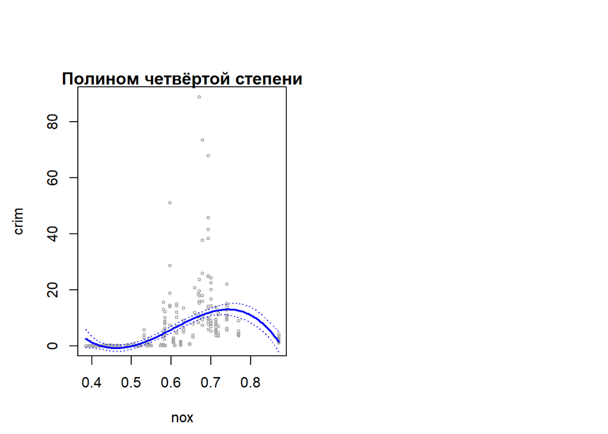

```r
# границы изменения переменной age
noxlims <- range(nox)
# значения age, для которых делаем прогноз (от min до max с шагом 1)
nox.grid <- seq(noxlims[1], noxlims[2], length = 200)
# рассчитать прогнозы и их стандартные ошибки
preds <- predict(fit, newdata = list(nox = nox.grid), se = T)
# границы доверительного интервала
se.bands <- cbind(preds$fit + 2*preds$se.fit,
                  preds$fit - 2*preds$se.fit)
par(mfrow = c(1, 2), mar = c(4.5, 4.5, 1, 1), oma = c(0, 0, 4, 0))
# наблюдения
plot(nox, crim, xlim = noxlims, cex = 0.5, col = 'darkgrey')+
title('Полином четвёртой степени')+
lines(nox.grid, preds$fit , lwd = 2, col = 'blue')+
matlines(nox.grid, se.bands, lwd = 1, col = 'blue', lty = 3)
```

Убедимся, что прогнозы по моделям с различными вызовами `poly()` совпадают.

```r
# прогнозы по второму вызову модели
preds2 <- predict(fit.2, newdata = list(nox = nox.grid), se = T)
# максимальное расхождение между прогнозами по двум вариантам вызова модели
max(abs(preds$fit - preds2$fit))
```

```
## [1] 1.910028e-12
```

Теперь подбираем степень полинома, сравнивая модели со степенями от 1 до 5 с помощью дисперсионного анализа (ANOVA).

```r
fit.1 <- lm(crim ~ nox, data = Boston)
fit.2 <- lm(crim ~ poly(nox, 2), data = Boston)
fit.3 <- lm(crim ~ poly(nox, 3), data = Boston)
fit.4 <- lm(crim ~ poly(nox, 4), data = Boston)
fit.5 <- lm(crim ~ poly(nox, 5), data = Boston)
round(anova(fit.1, fit.2, fit.3, fit.4, fit.5), 2)
```

|  | Res.Df | RSS | Df | Sum of Sq | F | Pr(>F) |
| --- | --- | --- | --- | --- | --- | --- |
| 1 | 504 | 30741.82 | NA | NA | NA | NA |
| 2 | 503 | 29910.73 | 1 | 831.09 | 16.49 | 0.00 |
| 3 | 502 | 26267.17 | 1 | 3643.56 | 72.31 | 0.00 |
| 4 | 501 | 26266.12 | 1 | 1.05 | 0.02 | 0.89 |
| 5 | 500 | 25193.33 | 1 | 1072.78 | 21.29 | 0.00 |

## Локальная регрессия

```r
noxlims <- range(nox)
nox.grid <- seq(noxlims[1], noxlims[2], length = 200)
fit <- loess(crim ~ nox, span = 0.2, data = Boston)
fit2 <- loess(crim ~ nox, span = 0.5, data = Boston)
plot(nox, crim, xlim = noxlims, cex = 0.5, col = 'darkgrey')+
title('Локальная регрессия')+
lines(nox.grid, predict(fit, data.frame(nox = nox.grid)),col = 'red', lwd = 2)+
lines(nox.grid, predict(fit2, data.frame(nox = nox.grid)),col = 'blue', lwd = 2)
```

```
## integer(0)
```

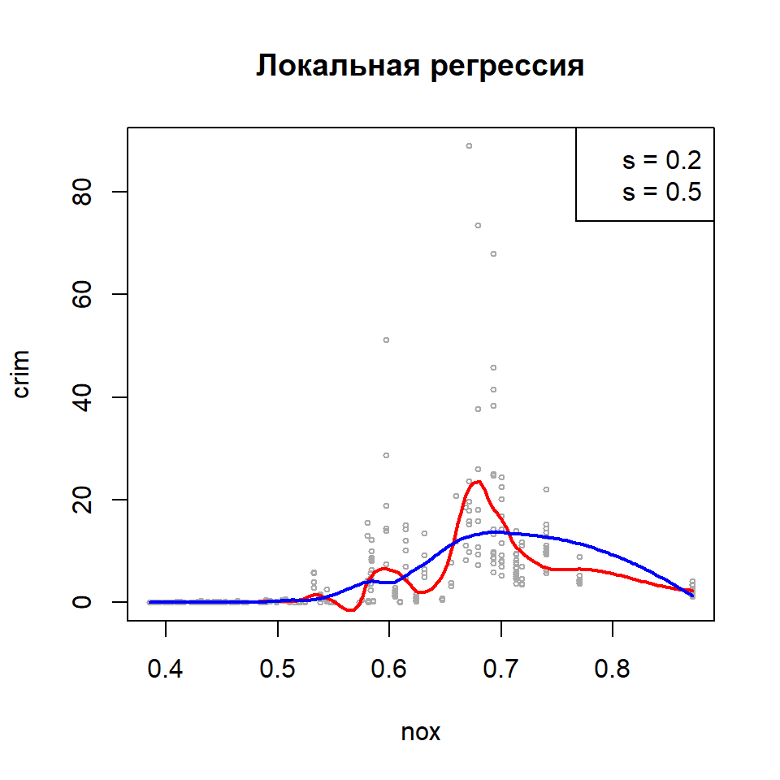

```r
legend('topright',c('s = 0.2', 's = 0.5'))
```

## Обобщённые аддитивные модели (GAM) с непрерывным откликом

Построим GAM на натуральных сплайнах степеней 4 (`indus`), 5 (`nox`) с категориальным предиктором `chas`.

```r
# GAM на натуральных сплайнах
gam.ns <- gam(crim ~ ns(indus, 4) + ns(nox, 5) + chas, data = Boston)
```

Также построим модель на сглаживающих сплайнах.

```r
# GAM на сглаживающих сплайнах
gam.m3 <- gam(crim ~ s(indus, 4) + s(nox, 5) + chas, data = Boston)
```

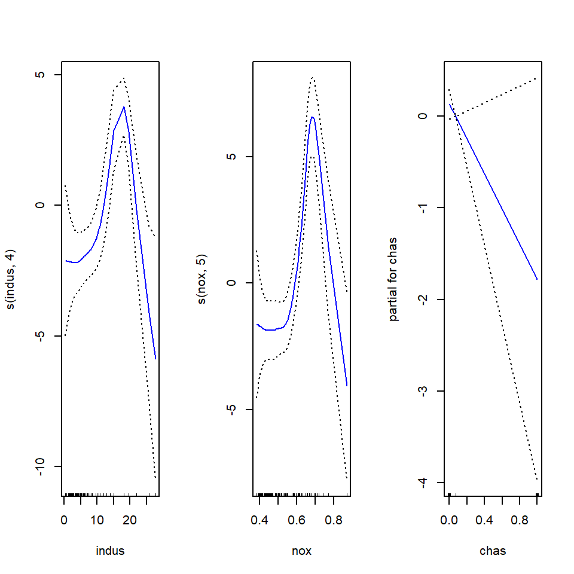

```r
par(mfrow = c(1, 3))
plot(gam.m3, se = T, col = 'blue')
```

```r
par(mfrow = c(1, 1))
```

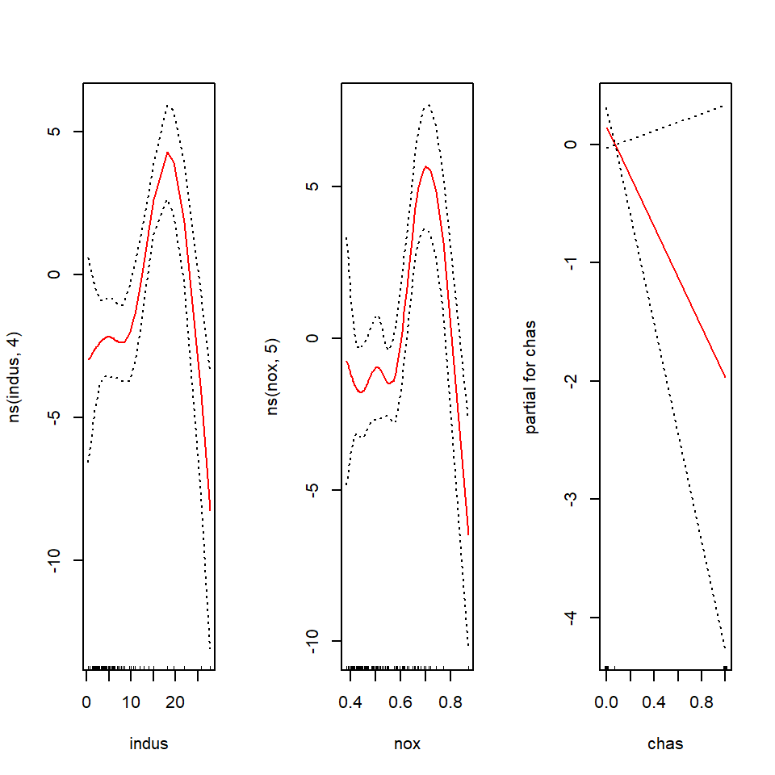

```r
par(mfrow = c(1, 3))
plot(gam.ns, se = T, col = 'red')
```

```r
par(mfrow = c(1, 1))
```

```r
gam.m1 <- gam(crim ~ s(nox, 5) + chas, data = Boston)
gam.m2 <- gam(crim ~ indus + s(nox, 5) + chas, data = Boston)
anova(gam.m1, gam.m2, gam.m3, test = 'F')
```

|  | Resid. Df | Resid. Dev | Df | Deviance | F | Pr(>F) |
| --- | --- | --- | --- | --- | --- | --- |
| 1 | 499.0001 | 24420.37 | NA | NA | NA | NA |
| 2 | 498.0001 | 24224.98 | 1.000000 | 195.385 | 4.339285 | 3.775519e-02 |
| 3 | 495.0002 | 22288.37 | 2.999898 | 1936.610 | 14.337147 | 5.690268e-09 |

Третья модель статистически лучше второй.

```r
# сводка по модели gam.m3
summary(gam.m3)
```

```
##
## Call: gam(formula = crim ~ s(indus, 4) + s(nox, 5) + chas, data = Boston)
## Deviance Residuals:
##     Min      1Q  Median      3Q     Max
## -9.4891 -1.9341  0.1456  0.3604 75.1531
##
## (Dispersion Parameter for gaussian family taken to be 45.027)
##
##     Null Deviance: 37363.22 on 505 degrees of freedom
## Residual Deviance: 22288.37 on 495.0002 degrees of freedom
## AIC: 3375.319
##
## Number of Local Scoring Iterations: 2
##
## Anova for Parametric Effects
##              Df  Sum Sq Mean Sq  F value    Pr(>F)
## s(indus, 4)   1  5144.7  5144.7 114.2576 < 2.2e-16 ***
## s(nox, 5)     1   604.5   604.5  13.4251 0.0002751 ***
## chas          1   118.1   118.1   2.6234 0.1059351
## Residuals   495 22288.4    45.0
## ---
## Signif. codes:  0 '***' 0.001 '**' 0.01 '*' 0.05 '.' 0.1 ' ' 1
##
## Anova for Nonparametric Effects
##             Npar Df Npar F     Pr(F)
## (Intercept)
## s(indus, 4)       3 17.358 9.903e-11 ***
## s(nox, 5)         4 21.311 3.331e-16 ***
## chas
## ---
## Signif. codes:  0 '***' 0.001 '**' 0.01 '*' 0.05 '.' 0.1 ' ' 1
```

Работаем с моделью `gam.m3`.

```r
# прогноз по обучающей выборке
preds <- predict(gam.m3, newdata = Boston)
```

Также можно использовать в GAM локальные регрессии.

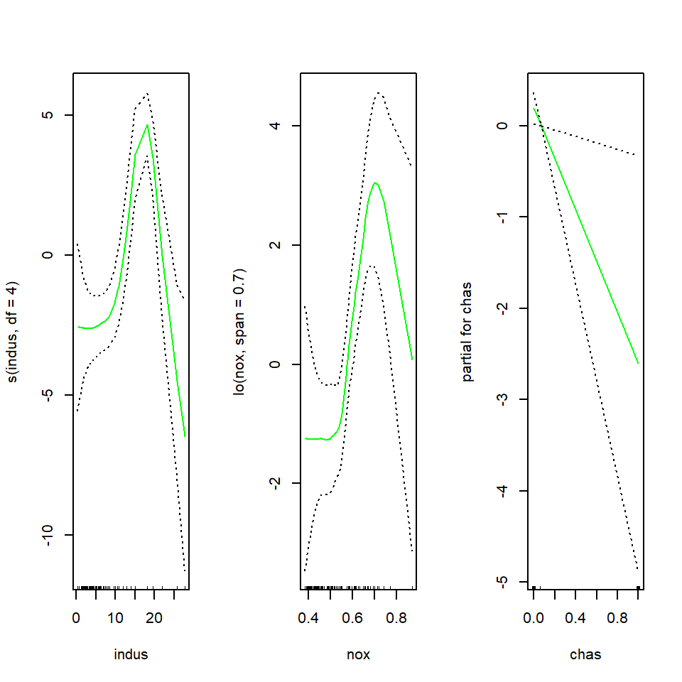

```r
# GAM на локальных регрессиях
gam.lo <- gam(crim ~ s(indus, df = 4) + lo(nox, span = 0.7) + chas,
              data = Boston)
par(mfrow = c(1, 3))
plot(gam.lo, se = T, col = 'green')
```

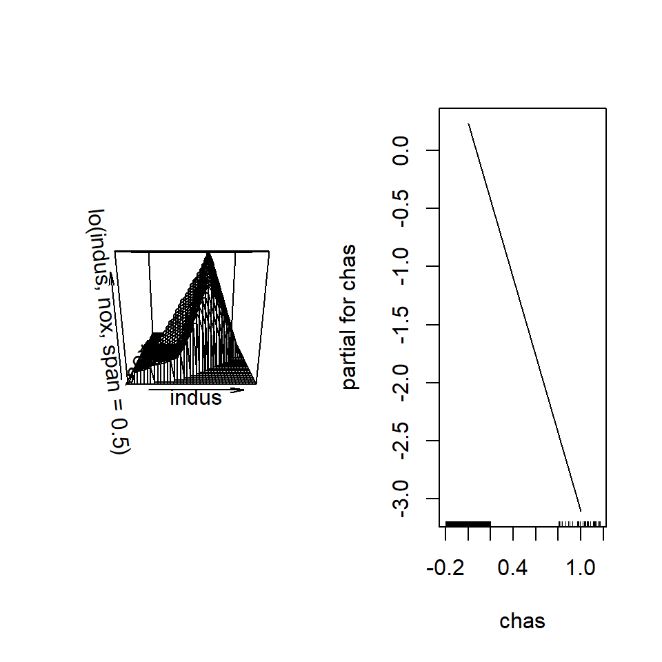

```r
par(mfrow = c(1, 1))
# модель со взаимодействием регрессоров indus и nox
gam.lo.i <- gam(crim ~ lo(indus, nox, span = 0.5) + chas, data = Boston)
par(mfrow = c(1, 2))
plot(gam.lo.i)
```

```r
par(mfrow = c(1, 1))
```

```r
detach(Boston)
```